# FinalP1

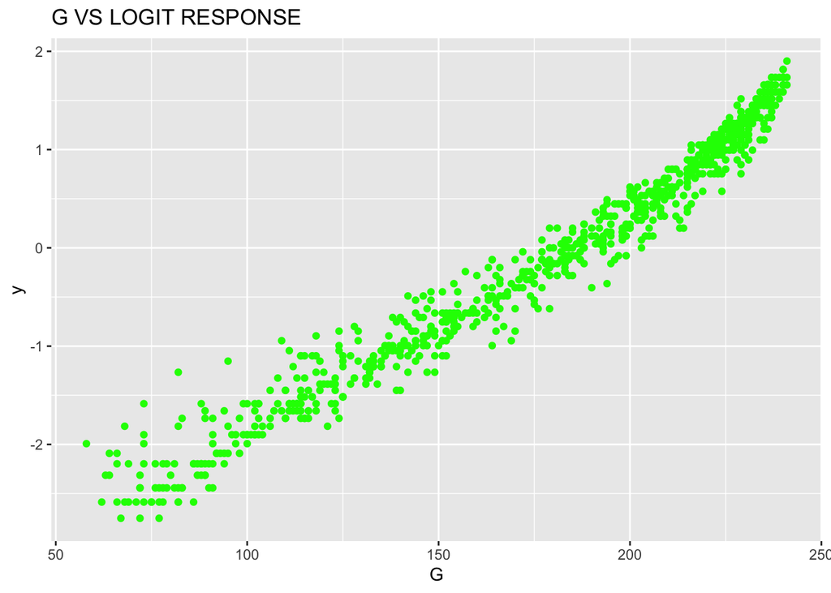

```r
dfii %>% ggplot(aes(x = G, y = y)) + geom_point(color = "green") + labs(title = "G VS LOGIT RESPONSE")
```

Green vs Logit response seems to look like a very strong linear relationship.

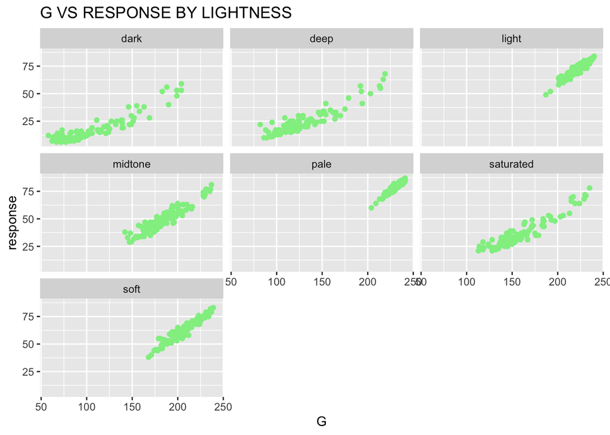

```r
dfii %>% ggplot(aes(x = G, y = response)) + geom_point(color = "lightgreen") + facet_wrap(~ Lightness) + labs(title = "G VS RESPONSE BY LIGHTNESS")
```

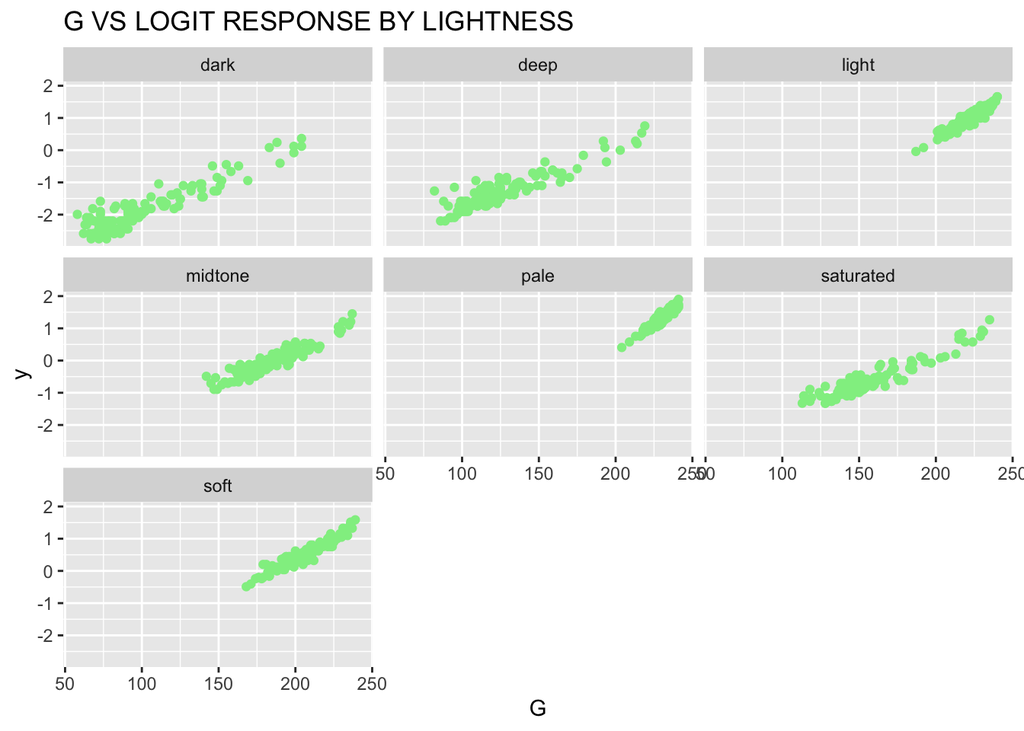

```r
dfii %>% ggplot(aes(x = G, y = y)) + geom_point(color = "lightgreen") + facet_wrap(~ Lightness) + labs(title = "G VS LOGIT RESPONSE BY LIGHTNESS")
```

We can see this partial clustering happening with grouping by lightness (as we saw in red as well). The ones that seem to cluster most are (pale, light, and soft).

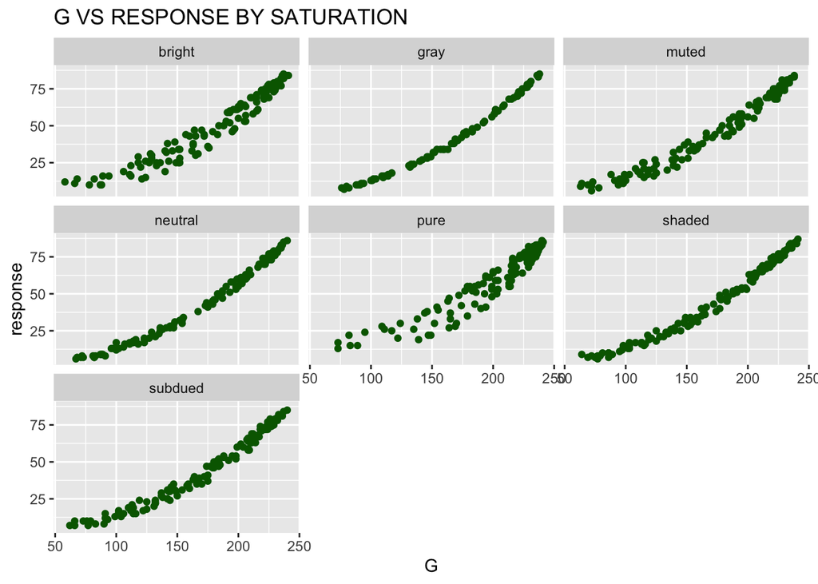

```r
dfii %>% ggplot(aes(x = G, y = response)) + geom_point(color = "darkgreen") + facet_wrap(~ Saturation) + labs(title = "G VS RESPONSE BY SATURATION")
```

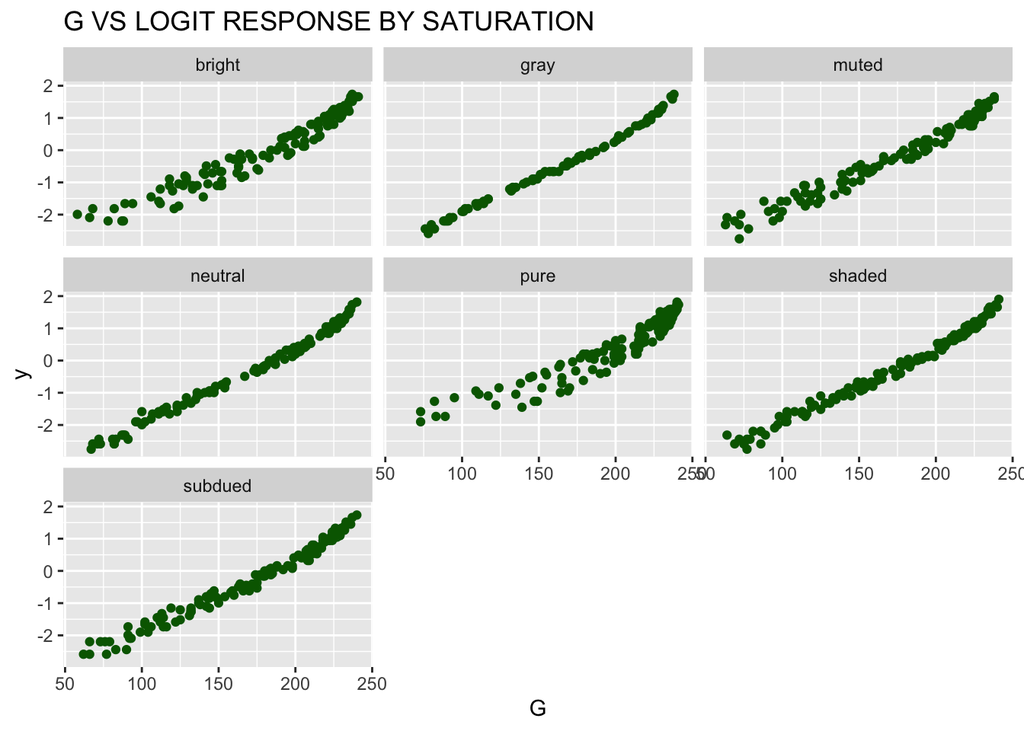

```r
dfii %>% ggplot(aes(x = G, y = y)) + geom_point(color = "darkgreen") + facet_wrap(~ Saturation) + labs(title = "G VS LOGIT RESPONSE BY SATURATION")
```

All of the logit responses vs green look extremely linear when stratified by saturation. This could be extremely useful in predicting logit output. The strongest relationships appear to be neutral, gray, shaded, and subdued.

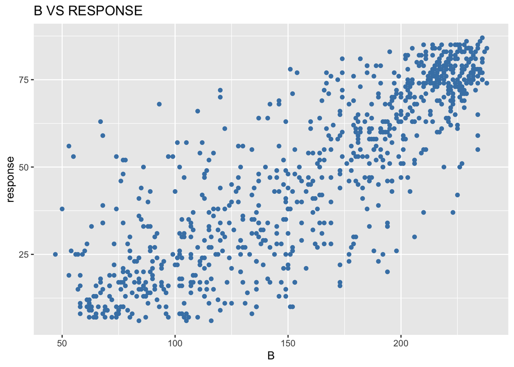

```r
dfii %>% ggplot(aes(x = B, y = response)) + geom_point(color = "steelblue") + labs(title = "B VS RESPONSE")
```

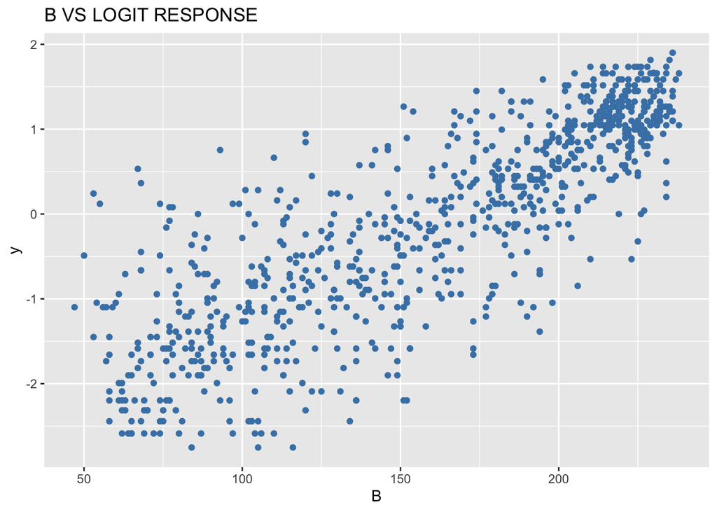

```r
dfii %>% ggplot(aes(x = B, y = y)) + geom_point(color = "steelblue") + labs(title = "B VS LOGIT RESPONSE")
```

Blue seems to follow a linear relationship with logit response, though it seems to be relatively weak.

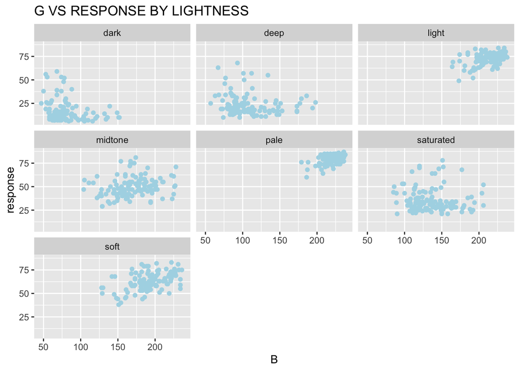

```r
dfii %>% ggplot(aes(x = B, y = response)) + geom_point(color = "lightblue") + facet_wrap(~ Lightness) + labs(title = "G VS RESPONSE BY LIGHTNESS")
```

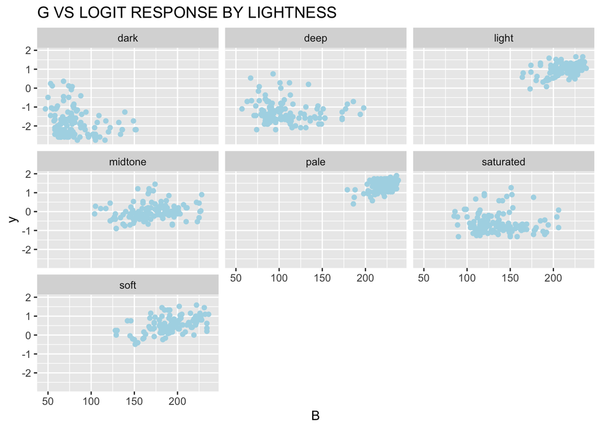

```r
dfii %>% ggplot(aes(x = B, y = y)) + geom_point(color = "lightblue") + facet_wrap(~ Lightness) + labs(title = "G VS LOGIT RESPONSE BY LIGHTNESS")
```

Again, we can see the clustering when we group by lightness.

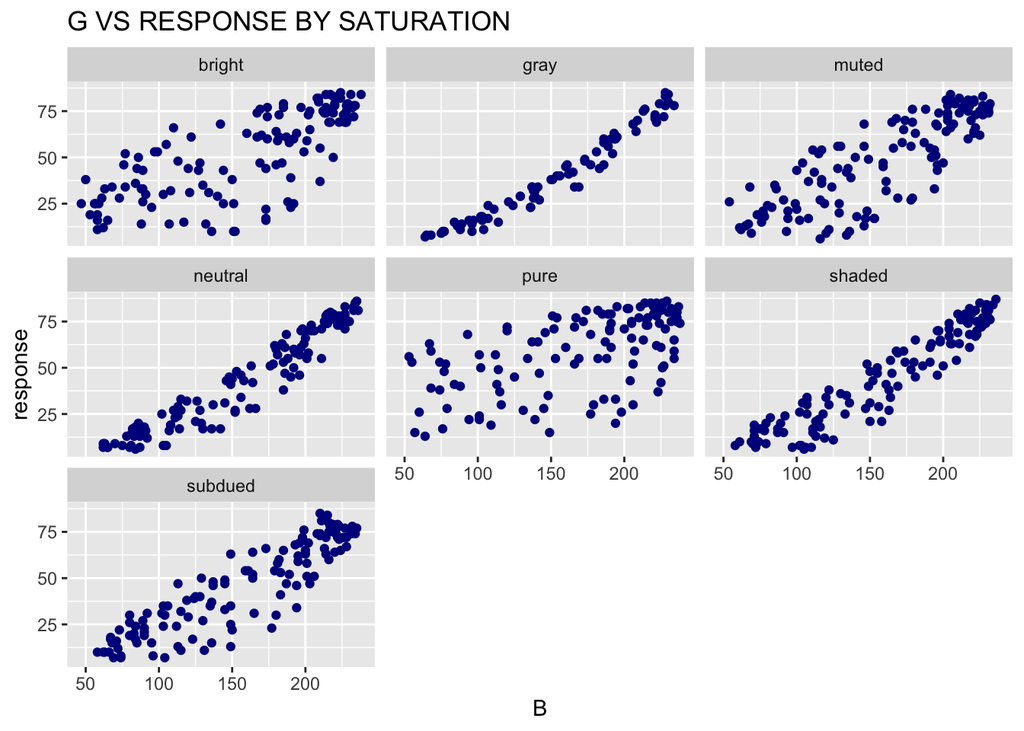

```r
dfii %>% ggplot(aes(x = B, y = response)) + geom_point(color = "darkblue") + facet_wrap(~ Saturation) + labs(title = "G VS RESPONSE BY SATURATION")
```

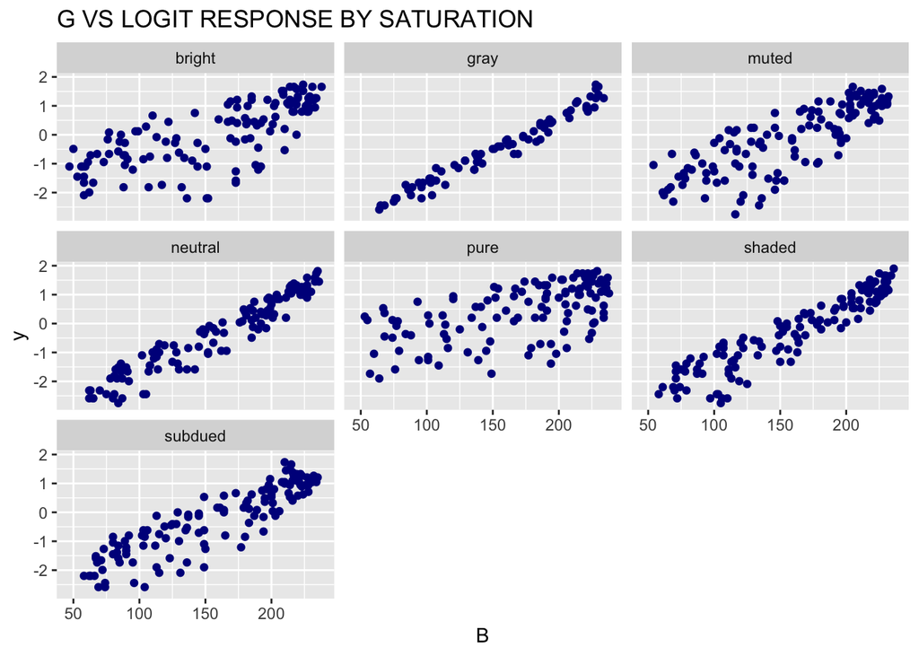

```r
dfii %>% ggplot(aes(x = B, y = y)) + geom_point(color = "darkblue") + facet_wrap(~ Saturation) + labs(title = "G VS LOGIT RESPONSE BY SATURATION")
```

We can also, again, see linear relationships appear when we stratify by saturation. The strongest appearance of a linear relationship appear to be neutral, gray, shaded, and subdued saturation levels.

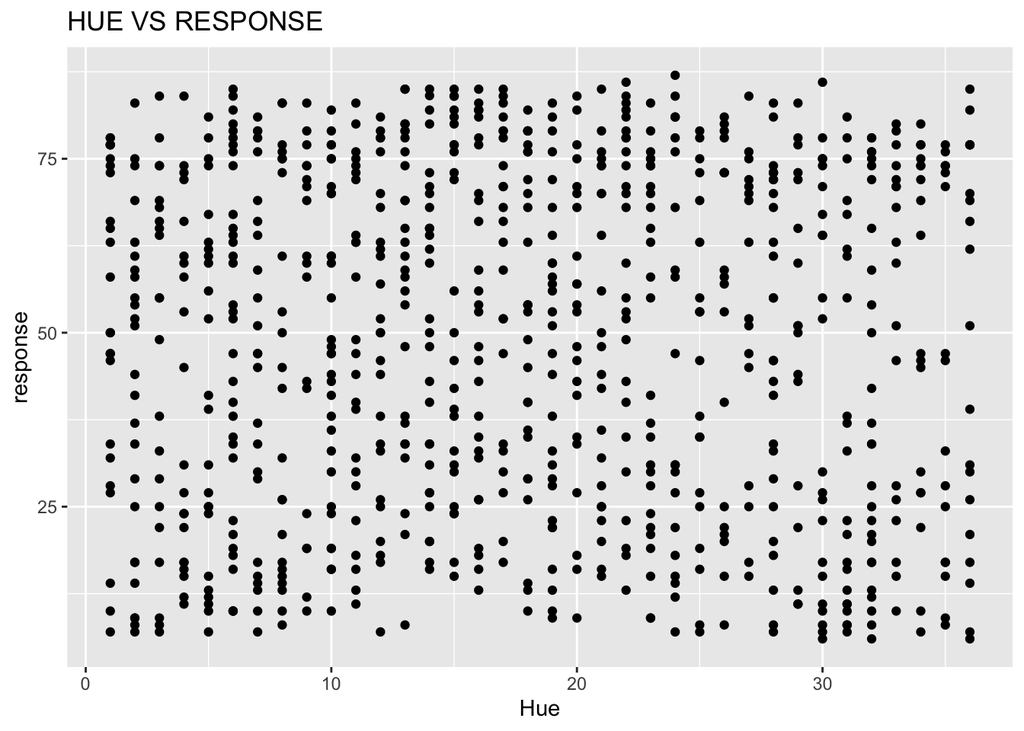

```r
dfii %>% ggplot(aes(x = Hue, y = response)) + geom_point(color = "black") + labs(title = "HUE VS RESPONSE")
```

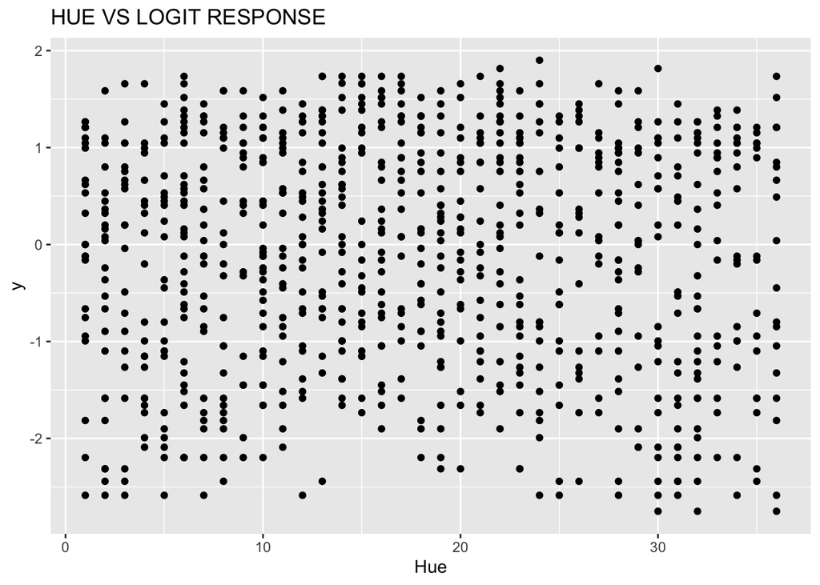

```r
dfii %>% ggplot(aes(x = Hue, y = y)) + geom_point(color = "black") + labs(title = "HUE VS LOGIT RESPONSE")
```

Hue vs. logit response appears to be almost purely noise. There is no obvious relationship here.

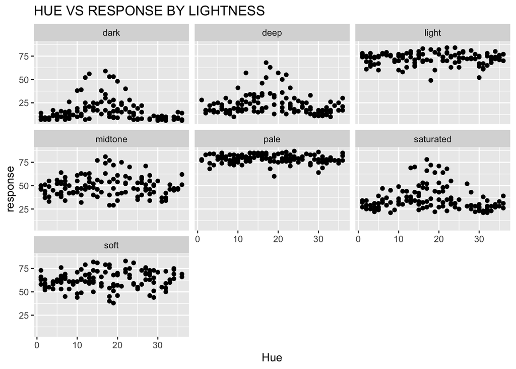

```r
dfii %>% ggplot(aes(x = Hue, y = response)) + geom_point(color = "black") + facet_wrap(~ Lightness) + labs(title = "HUE VS RESPONSE BY LIGHTNESS")
```

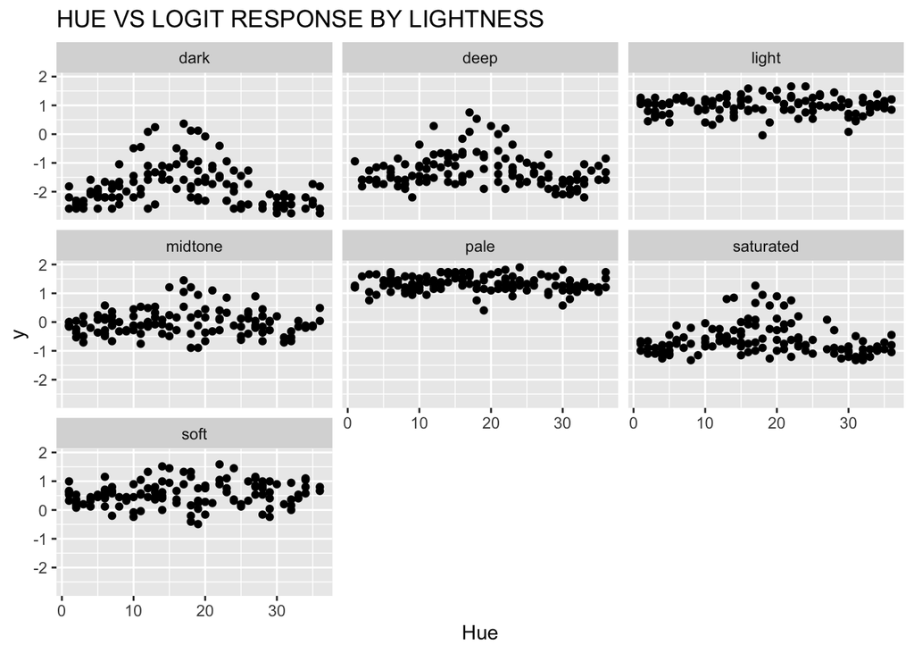

```r
dfii %>% ggplot(aes(x = Hue, y = y)) + geom_point(color = "black") + facet_wrap(~ Lightness) + labs(title = "HUE VS LOGIT RESPONSE BY LIGHTNESS")
```

When stratified by lightness, we can see some almost horizontal ranges form. This means that regardless of hue (or any other continuous variable), there is a range of logit responses that the lightness level will fall under. This suggests that lightness alone, can be useful in predicting logit response. Some of the lightness levels (notably dark, deep, and saturated), seem to have higher logit responses are closer to the middle (~10-20).

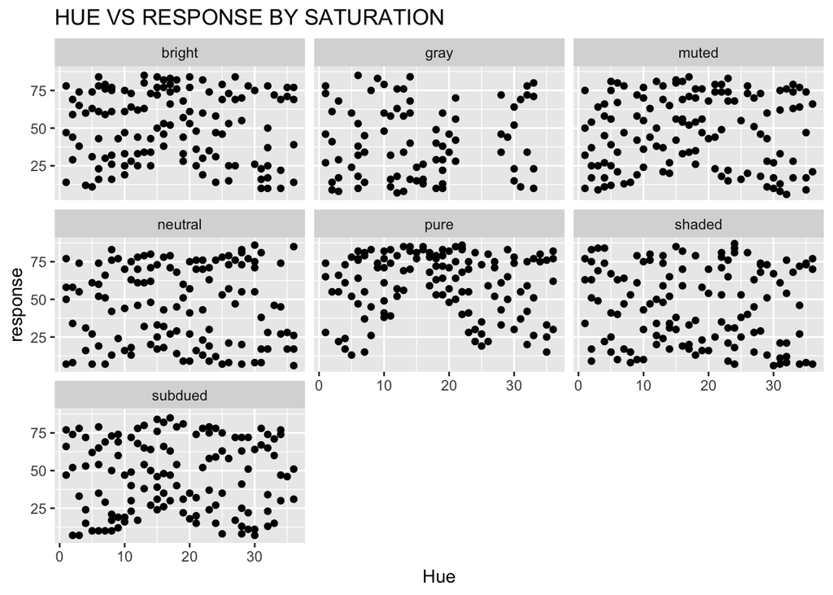

```r
dfii %>% ggplot(aes(x = Hue, y = response)) + geom_point(color = "black") + facet_wrap(~ Saturation) + labs(title = "HUE VS RESPONSE BY SATURATION")
```

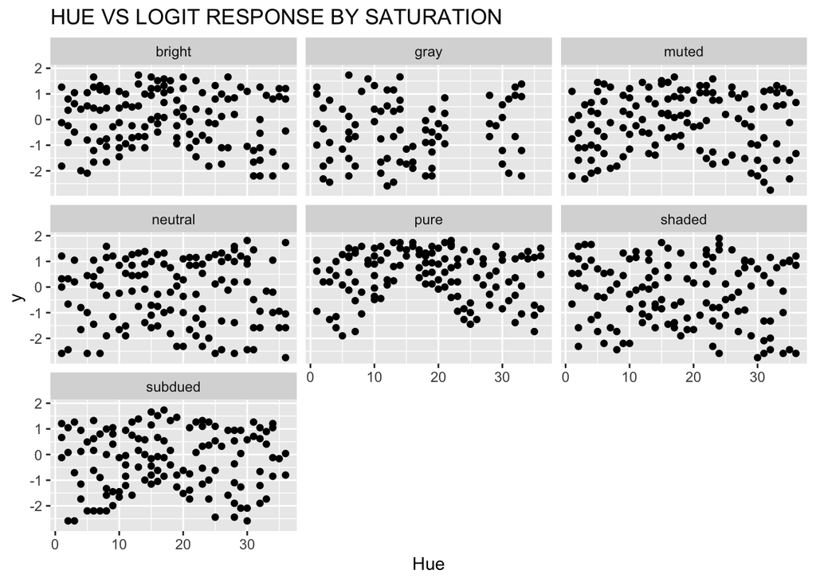

```r
dfii %>% ggplot(aes(x = Hue, y = y)) + geom_point(color = "black") + facet_wrap(~ Saturation) + labs(title = "HUE VS LOGIT RESPONSE BY SATURATION")
```

There seems to be little relationship between hue and logit response, even when stratified by saturation level.

• Can you identify any clear trends? Do the trends depend on the categorical INPUTS?

Many trends appear when we visualise the relationship between the continuous variables and the response/logit response. Some stronger trends appear when you group by categorical inputs.

• How can you visualize the behavior of the binary outcome with respect to the continuous inputs? How can you visualize the behavior of the binary outcome with respect to the categorical INPUTS?

The first can be done with a density plot (already done above).

Plotting categorical variables relative to the binary inputs can be done with a side-by-side bar chart as follows:

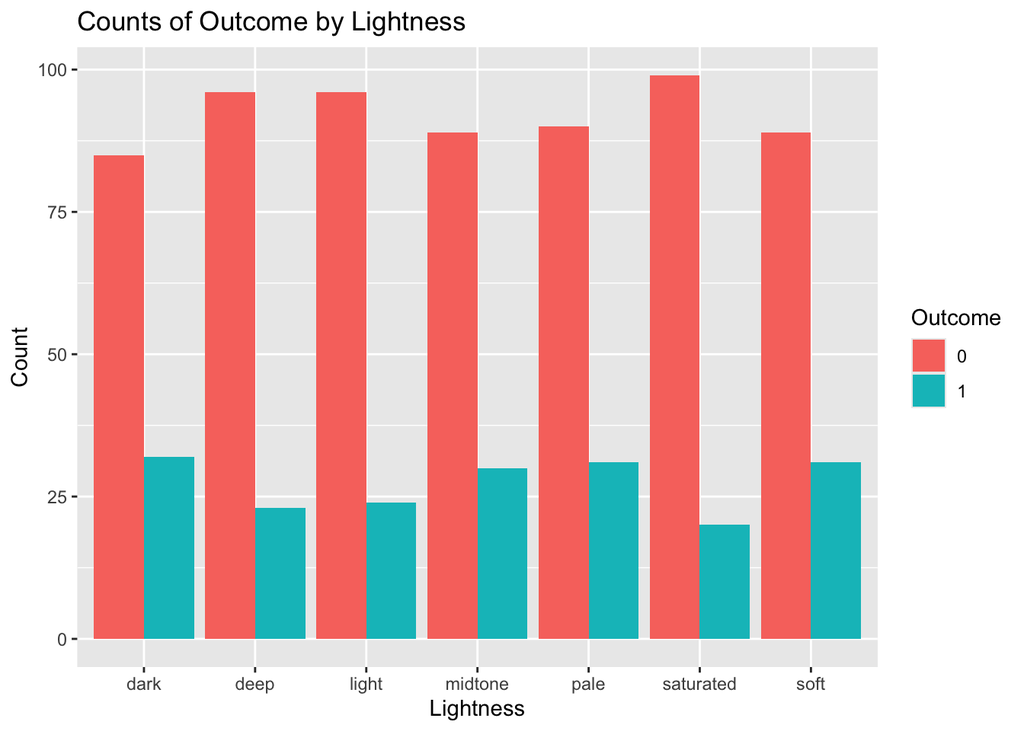

```r
df %>%
  ggplot(aes(x = Lightness, fill = as.factor(outcome))) +
  geom_bar(position = "dodge") +
  labs(title = "Counts of Outcome by Lightness",
       x = "Lightness",
       y = "Count",
       fill = "Outcome")
```

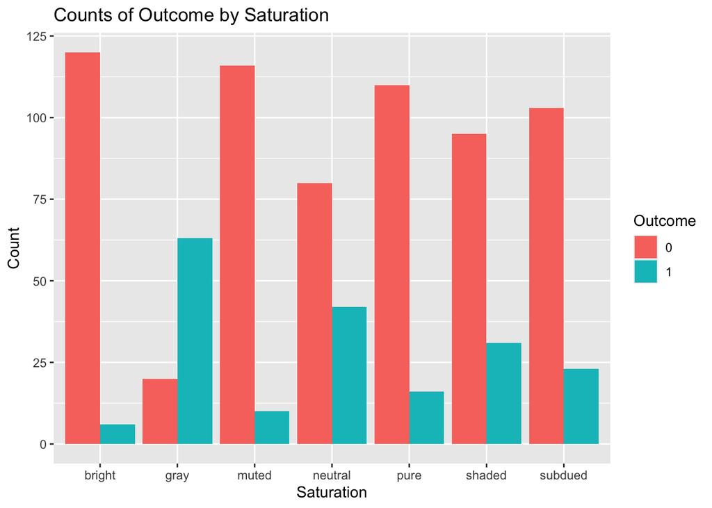

```r
df %>%
  ggplot(aes(x = Saturation, fill = as.factor(outcome))) +
  geom_bar(position = "dodge") +
  labs(title = "Counts of Outcome by Saturation",
       x = "Saturation",
       y = "Count",
       fill = "Outcome")
```

Lightness seems to have a relatively constant ratio of 0 and 1 outcomes per each lightness level. However, Saturations eems to have a widely varying ratio of 0s to 1s depending on the saturation level. This might be useful in predictions.